# Project D - Predicting Flight Delays

Manish Walia, Priyanka Karia, Mohit Gattani, Akshita Garg

December 01, 2017

### Preamble: Loading packages and data

```r
library(ggplot2)
library(ISLR)
library(MASS)
library(partykit)
library(caret)
library(rpart)
library(randomForest)
library(pROC)
library(plyr)
library(dplyr)
library(knitr)
library(glmnet)
library(openxlsx)
library(gam)
```

### 0. Read Data

```r
# Read the flight delay data for Pittsburgh for the year 2006

flight.delay <- read.csv("http://www.andrew.cmu.edu/user/achoulde/95791/projects/Project%20D/all_PIT_2006.csv",header = TRUE, sep = ",")
```

### 1. Variable Selection : Based on Redundant information

```r
flight.delay <- flight.delay %>% dplyr :: select(-c(AirlineID, Carrier, Flights, ArrDel15, ArrDel30, ArrDelSys15, ArrDelSys30, ArrTimeBlk, DepDel30, DepDelSys15, DepDelSys30, DepTimeBlk, OriginCityName, OriginStateFips, OriginStateName, OriginState, DestCityName, DestState, DestStateFips, DestStateName, DestWac, WheelsOff, WheelsOn, Year, Quarter, DayofMonth, OriginWac, Cancelled))
```

**In the given data, many fields were present which were either redundant or were derived from another field.**

**- AirlineID, Carrier and UniquCarrier denoted the same information so we kept UniqueCarrier and removed the other two fields.**  
**- There were many fields that contained origin and destination information such as Origin/Dest, OriginCityName/DestCityName, OriginStateName/DestStateName, OriginState/DestState, OriginWac/DestWac. We decided to include only the Origin and Dest fields which contains the city codes.**  
**- There were many derived fields that were derived from ArrDelay and DepDelay fields such as ArrDel15, ArrDel30, ArrDelSys15, ArrDelSys30, ArrTimeBlk, DepDel30, DepDelSys15, DepDelSys30, DepTimeBlk.**  
**- Year, Quarter, DayofMonth are derived from the FlightDate field.**  
**- Cancelled and CancellationCode indicated the same information. So, we excluded the Cancelled field.**  
**- WheelsOff and WheelsOn are dervied from the DepTime/ArrTime and TaxiOut/TaxiIn fields.**  
**Hence, these fields were excluded from our analysis.**

### 2. Creating Summary of data

```r
field.summary <- function(df)
{

#Finding column names
field.name <- data.frame(colnames = colnames(df, do.NULL = TRUE, prefix = "col"))

#Finding class type
data.type <- data.frame(lapply(df, class))
data.type <- as.data.frame(t(data.type))
field.name <- mutate(field.name, dataType = data.type$V1)

#Finding factors
factor.level <- data.frame(factorLevels = sapply(df[], nlevels))
field.name <- mutate(field.name, factorLevels = factor.level$factorLevels)

#Finding mean
mean <-  data.frame(mean = ifelse(sapply(df, is.numeric), lapply(df, mean, na.rm = T), 0))
mean <- as.data.frame(t(mean))
field.name <- mutate(field.name, mean = mean$V1)

#Finding sd
sd <-  data.frame(sd = ifelse(sapply(df, is.numeric), lapply(df, sd, na.rm = T), 0))
sd <- as.data.frame(t(sd))
field.name <- mutate(field.name, sd = sd$V1)

#Finding missing values
missing.value <- data.frame(missingValues = colSums(is.na(df)))
field.name <- mutate(field.name, missingValues = missing.value$missingValues)

return(field.name)

}
summary <- field.summary(flight.delay)

#Printing Summary
kable(summary)
```

| colnames | dataType | factorLevels | mean | sd | missingValues |
| --- | --- | --- | --- | --- | --- |
| Month | integer | 0 | 6.6510680 | 3.4368200 | 0 |
| UniqueCarrier | factor | 14 | 0.0000000 | 0.0000000 | 0 |
| FlightDate | factor | 365 | 0.0000000 | 0.0000000 | 0 |
| DayOfWeek | integer | 0 | 3.9150025 | 1.9859848 | 0 |
| FlightNum | integer | 0 | 2084.3742733 | 1908.4594383 | 0 |
| TailNum | factor | 2443 | 0.0000000 | 0.0000000 | 0 |
| ActualElapsedTime | integer | 0 | 118.0722429 | 58.7632505 | 1786 |
| CRSElapsedTime | integer | 0 | 119.0200223 | 58.2284717 | 0 |
| AirTime | integer | 0 | 94.2310913 | 59.3188987 | 1786 |
| ArrDelay | integer | 0 | 8.7367913 | 36.8176119 | 1786 |
| ArrTime | integer | 0 | 1470.2569613 | 492.3641511 | 1786 |
| CRSArrTime | integer | 0 | 1480.4350038 | 468.5670710 | 0 |
| DepDel15 | integer | 0 | 0.1929980 | 0.3946535 | 0 |
| DepDelay | integer | 0 | 10.0134708 | 32.9026234 | 1631 |
| DepTime | integer | 0 | 1334.4336909 | 469.9414480 | 1631 |
| CRSDepTime | integer | 0 | 1328.1427368 | 454.9513147 | 0 |
| Origin | factor | 35 | 0.0000000 | 0.0000000 | 0 |
| Dest | factor | 36 | 0.0000000 | 0.0000000 | 0 |
| Distance | integer | 0 | 648.3742733 | 499.8832933 | 0 |
| DistanceGroup | integer | 0 | 3.1876475 | 2.0110311 | 0 |
| TaxiIn | integer | 0 | 6.6297396 | 6.5124475 | 0 |
| TaxiOut | integer | 0 | 16.7994923 | 12.3105288 | 0 |
| CancellationCode | factor | 4 | 0.0000000 | 0.0000000 | 0 |
| Diverted | integer | 0 | 0.0016325 | 0.0403719 | 0 |
| CarrierDelay | integer | 0 | 2.9370471 | 15.8498249 | 0 |
| WeatherDelay | integer | 0 | 0.6342581 | 8.3901390 | 0 |
| NASDelay | integer | 0 | 4.2492838 | 16.9537567 | 0 |
| SecurityDelay | integer | 0 | 0.0157988 | 0.8257001 | 0 |
| LateAircraftDelay | integer | 0 | 4.8369355 | 20.8477446 | 0 |

- **The above function is used to depict a summary of the available data. It shows us the column names, datatypes, mean and standard deviation of each field and also indicates how many fields have missing values and their count.**

### 3. Filling missing data

```r
#Filling ActualElapsedTime with CRSElapsedTime
flight.delay$ActualElapsedTime <- ifelse(is.na(flight.delay$ActualElapsedTime) == "TRUE", flight.delay$CRSElapsedTime, flight.delay$ActualElapsedTime)

#Filling ArrTime with CRSArrTime
flight.delay$ArrTime <- ifelse(is.na(flight.delay$ArrTime) == "TRUE", flight.delay$CRSArrTime, flight.delay$ArrTime)

#Filling DepTime with CRSDepTime
flight.delay$DepTime <- ifelse(is.na(flight.delay$DepTime) == "TRUE", flight.delay$CRSDepTime, flight.delay$DepTime)

#Filling ArrDelay with 0
flight.delay$ArrDelay <- ifelse(is.na(flight.delay$ArrDelay) == "TRUE" | flight.delay$ArrDelay < 0, 0, flight.delay$ArrDelay)

#Filling DepDelay with 0
flight.delay$DepDelay <- ifelse(is.na(flight.delay$DepDelay) == "TRUE" | flight.delay$DepDelay < 0, 0, flight.delay$DepDelay)

#Filling AirTime with 0
flight.delay$AirTime <- ifelse(is.na(flight.delay$AirTime) == "TRUE",0,flight.delay$AirTime)

summary <- field.summary(flight.delay)

#Printing Summary
kable(summary)
```

| colnames | dataType | factorLevels | mean | sd | missingValues |
| --- | --- | --- | --- | --- | --- |
| Month | integer | 0 | 6.6510680 | 3.4368200 | 0 |
| UniqueCarrier | factor | 14 | 0.0000000 | 0.0000000 | 0 |
| FlightDate | factor | 365 | 0.0000000 | 0.0000000 | 0 |
| DayOfWeek | integer | 0 | 3.9150025 | 1.9859848 | 0 |
| FlightNum | integer | 0 | 2084.3742733 | 1908.4594383 | 0 |
| TailNum | factor | 2443 | 0.0000000 | 0.0000000 | 0 |
| ActualElapsedTime | integer | 0 | 117.7888861 | 58.4891169 | 0 |
| CRSElapsedTime | integer | 0 | 119.0200223 | 58.2284717 | 0 |
| AirTime | numeric | 0 | 92.4585019 | 60.1367821 | 0 |
| ArrDelay | numeric | 0 | 14.0654175 | 33.4860917 | 0 |
| ArrTime | integer | 0 | 1472.2876959 | 491.8264955 | 0 |
| CRSArrTime | integer | 0 | 1480.4350038 | 468.5670710 | 0 |
| DepDel15 | integer | 0 | 0.1929980 | 0.3946535 | 0 |
| DepDelay | numeric | 0 | 11.9998947 | 31.7066446 | 0 |
| DepTime | integer | 0 | 1336.1199339 | 469.6750944 | 0 |
| CRSDepTime | integer | 0 | 1328.1427368 | 454.9513147 | 0 |
| Origin | factor | 35 | 0.0000000 | 0.0000000 | 0 |
| Dest | factor | 36 | 0.0000000 | 0.0000000 | 0 |
| Distance | integer | 0 | 648.3742733 | 499.8832933 | 0 |
| DistanceGroup | integer | 0 | 3.1876475 | 2.0110311 | 0 |
| TaxiIn | integer | 0 | 6.6297396 | 6.5124475 | 0 |
| TaxiOut | integer | 0 | 16.7994923 | 12.3105288 | 0 |
| CancellationCode | factor | 4 | 0.0000000 | 0.0000000 | 0 |
| Diverted | integer | 0 | 0.0016325 | 0.0403719 | 0 |
| CarrierDelay | integer | 0 | 2.9370471 | 15.8498249 | 0 |
| WeatherDelay | integer | 0 | 0.6342581 | 8.3901390 | 0 |
| NASDelay | integer | 0 | 4.2492838 | 16.9537567 | 0 |
| SecurityDelay | integer | 0 | 0.0157988 | 0.8257001 | 0 |
| LateAircraftDelay | integer | 0 | 4.8369355 | 20.8477446 | 0 |

- **Based on the information we got from the summary function, we replaced the missing data in the above fields accordingly.**

### 4. Visualising Data and Extracting Insights

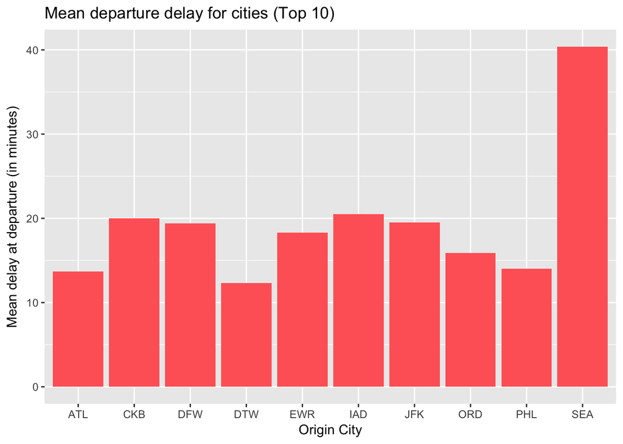

```r
#Summarizing departure delay with respect to origin
flight.delay.visual.dest.pit <- subset(flight.delay, Dest == "PIT")

flight.depdelay.origin <- dplyr ::summarise(group_by(flight.delay.visual.dest.pit, Origin), DepDelay = mean(DepDelay))

# Extracting top 10 origin delays
flight.depdelay.origin.top.10 <- flight.depdelay.origin %>%filter(rank(desc(DepDelay))<=10)

#Plotting top 10 delays
ggplot (data = flight.depdelay.origin.top.10, mapping = aes(x = Origin, y = DepDelay)) + geom_bar(stat = "identity", fill = "#FF6666") + labs(x = "Origin City",y = "Mean delay at departure (in minutes)", title = "Mean departure delay for cities (Top 10)")
```

- **The above graph shows that the flights arriving in Pittsburgh from other origin cities and their mean departure delay for the year 2006. This shows that the maximum flights coming from Seattle are delayed and the mean time of flights delayed for the same are 40 minutes. On the other hand, the mean flights delayed from Detroit(DTW) where the mean time of flights delayed are 12 minutes.**

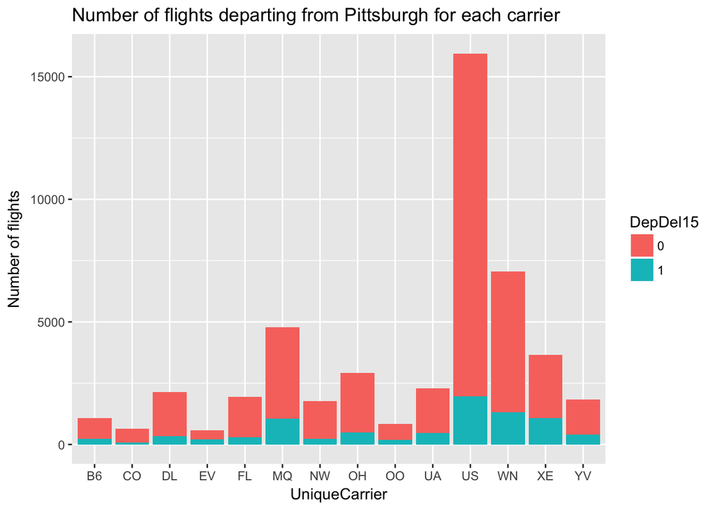

```r
# Total Flights departing from Pittsburgh with and without Delay for each carrier
flight.delay.visual.pit <- subset(flight.delay, Origin == "PIT")

flight.delay.visual.pit$DepDel15 <- as.factor(flight.delay.visual.pit$DepDel15)
ggplot(flight.delay.visual.pit, aes (x = UniqueCarrier)) + geom_histogram(aes(fill = DepDel15), stat = "count") + labs( y = "Number of flights", title = "Number of flights departing from Pittsburgh for each carrier")
```

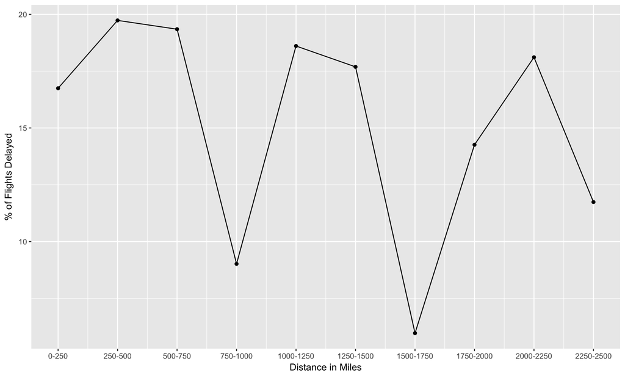

```r
#Percentage of flights delayed based on distance group

flight.delay.visual.pit$DepDel15 <- as.factor(flight.delay.visual.pit$DepDel15)
df1 <- ddply(flight.delay.visual.pit, .(DistanceGroup), nrow)
df2 <- ddply(flight.delay.visual.pit, .(DistanceGroup, DepDel15), nrow)
df2 <- df2[df2$DepDel15 == 1,]
delay.count.distGroup <- data.frame(cbind(DistanceGroup = df1$DistanceGroup, Total_Flights = df1$V1, Flights_Delayed = df2$V1, Percent_Flight_Delayed = df2$V1/df1$V1*100))

ggplot(delay.count.distGroup) +
  geom_line(aes(x = delay.count.distGroup$DistanceGroup, y = delay.count.distGroup$Percent_Flight_Delayed)) +
  geom_point(aes(x = delay.count.distGroup$DistanceGroup, y = delay.count.distGroup$Percent_Flight_Delayed)) +
  scale_x_continuous(breaks=c(1:10), labels=c("0-250","250-500","500-750","750-1000","1000-1250","1250-1500","1500-1750","1750-2000","2000-2250","2250-2500")) +
  xlab("Distance in Miles") + ylab("% of Flights Delayed")
```

- **The above graph shows that the distance and percentage of flights delayed are not correlated. Our assumption was that more the distance is the more the delay would be. However, there is no co-relation between the distance group and the percentage of flights delayed. Also, the above plot shows that the maximum delay is for the distance 250-500. And the least percentage of flights delayed is for the distance 1500-1750. This might be possible because of the more number of flights for short distances like for 250-500. And it is least for 1500-1750 because of less number of flights travelling for this distance.**

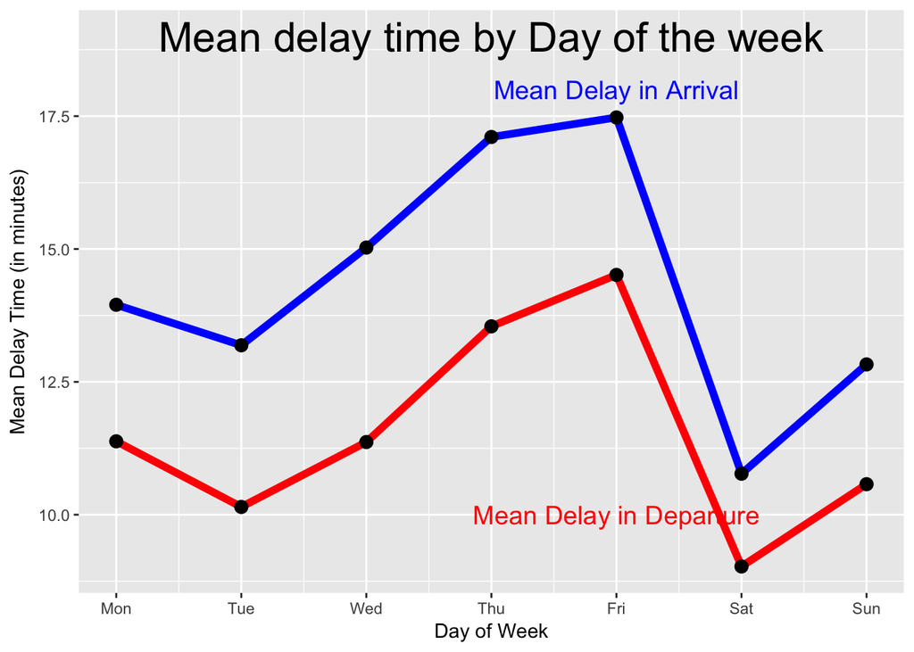

```r
#Mean delay time by day of Week
arr.delay.mean.dayOfWeek <- ddply( flight.delay.visual.pit, .(DayOfWeek), function(x) mean(x$ArrDelay) )
dep.delay.mean.dayOfWeek <- ddply( flight.delay.visual.pit, .(DayOfWeek), function(x) mean(x$DepDelay) )
mean.delay.dayOfWeek <- data.frame(cbind(DayOfWeek = arr.delay.mean.dayOfWeek$DayOfWeek, Mean_Arr_Delay =  arr.delay.mean.dayOfWeek$V1, Mean_Dep_Delay = dep.delay.mean.dayOfWeek$V1))

ggplot(mean.delay.dayOfWeek) + geom_line(aes(x = mean.delay.dayOfWeek$DayOfWeek, y = mean.delay.dayOfWeek$Mean_Arr_Delay), color = "Blue" , size=2) +
  geom_point(aes(x = mean.delay.dayOfWeek$DayOfWeek, y = mean.delay.dayOfWeek$Mean_Arr_Delay), size=3) +
  geom_line(aes(x = mean.delay.dayOfWeek$DayOfWeek, y = mean.delay.dayOfWeek$Mean_Dep_Delay), color = "Red", size=2) +
  geom_point(aes(x = mean.delay.dayOfWeek$DayOfWeek, y = mean.delay.dayOfWeek$Mean_Dep_Delay), size=3) +
  scale_x_continuous(breaks=c(1:7), labels=c("Mon","Tue","Wed","Thu","Fri","Sat","Sun")) +
  xlab("Day of Week") + ylab("Mean Delay Time (in minutes)") +
  annotate("text", x = 5, y=18, label = "Mean Delay in Arrival", color = "Blue" , size = 5) +
  annotate("text", x = 5, y=10, label = "Mean Delay in Departure", color = "Red", size = 5) +
  annotate("text", x = 4, y=19, label = "Mean delay time by Day of the week", color = "Black", size = 8)
```

- **The above graph shows the variation of Mean Delay Time and Days of Week. This shows that the maximum flights delayed are on Friday. This is directly related to the assumption that maximum people travel on Friday and the time taken by airline to board more number of passengers might be more. Also, there might be more number of flights running on Friday which might cause more congestion on airport as well as air conjestion. Hence, the flights are more delayed on Friday.**

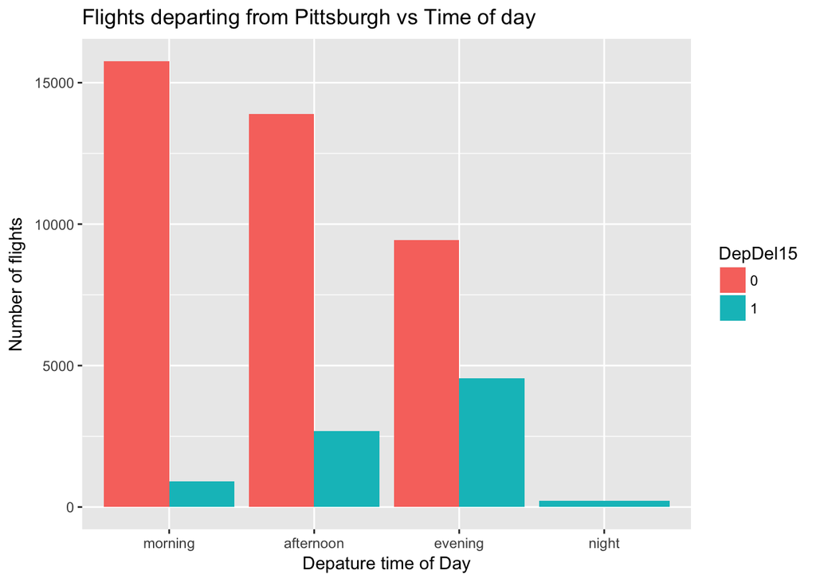

```r
#Adding Time of the day columns
dep.time.of.day <- vector()
arr.time.of.day <- vector()

for(i in 1:nrow(flight.delay.visual.pit))
{
  if(flight.delay.visual.pit$DepTime[i] >= 400 && flight.delay.visual.pit$DepTime[i] < 1000)
  {
    dep.time.of.day[i] <- "morning"
  } else if(flight.delay.visual.pit$DepTime[i] >= 1000 && flight.delay.visual.pit$DepTime[i] < 1600)
  {
    dep.time.of.day[i] <- "afternoon"
  } else if(flight.delay.visual.pit$DepTime[i] >= 1600 && flight.delay.visual.pit$DepTime[i] < 2200)
  {
    dep.time.of.day[i] <- "evening"
  } else if((flight.delay.visual.pit$DepTime[i] >= 2200 && flight.delay.visual.pit$DepTime[i] <= 2400) | (flight.delay.visual.pit$DepTime[i] >= 0000 && flight.delay.visual.pit$DepTime[i] < 400))
  {
    dep.time.of.day[i] <- "night"
  }
  if(flight.delay.visual.pit$ArrTime[i] >= 400 && flight.delay.visual.pit$ArrTime[i] < 1000)
  {
    arr.time.of.day[i] <- "morning"
  } else if(flight.delay.visual.pit$ArrTime[i] >= 1000 && flight.delay.visual.pit$ArrTime[i] < 1600)
  {
    arr.time.of.day[i] <- "afternoon"
  } else if(flight.delay.visual.pit$ArrTime[i] >= 1600 && flight.delay.visual.pit$ArrTime[i] < 2200)
  {
    arr.time.of.day[i] <- "evening"
  } else if((flight.delay.visual.pit$DepTime[i] >= 2200 && flight.delay.visual.pit$DepTime[i] <= 2400) | (flight.delay.visual.pit$DepTime[i] >= 0000 && flight.delay.visual.pit$DepTime[i] < 400))
  {
    arr.time.of.day[i] <- "night"
  }
}

flight.delay.visual.x <- data.frame(flight.delay.visual.pit, dep.time.of.day, arr.time.of.day)

flight.delay.visual.x$DepDel15 <- as.factor(flight.delay.visual.x$DepDel15)

flight.delay.visual.x$arr.time.of.day <- factor(flight.delay.visual.x$arr.time.of.day, levels = c("morning", "afternoon", "evening", "night"))

flight.delay.visual.x$dep.time.of.day <- factor(flight.delay.visual.x$dep.time.of.day, levels = c("morning", "afternoon", "evening", "night"))

ggplot(flight.delay.visual.x, aes(dep.time.of.day, ..count..)) + geom_bar(aes(fill = DepDel15), position = "dodge") + labs(x = "Depature time of Day", y = "Number of flights", title = "Flights departing from Pittsburgh vs Time of day")
```

- **The above graph plots the departure time of day versus the number of flights for more than 15 minutes delayed flights and less than 15 minutes delayed flights. The graph shows that the maximum flights are delayed in evening i.e. around 4500 flights which might be because of the fact that people leave for their destinations in the evening after office. Also, a surprising insight is that flights running in night i.e. from 10 pm till 4 am from Pittsburgh are all delayed. This is firstly because there are less flights running at night. Also, this might be because flights are getting delayed since morning till evening which is causing the flights at night to be delayed.**

# 5. Feature Engineering

```r
flight.delay <- arrange(flight.delay, FlightDate, TailNum, FlightNum)

flight.delay.pit <- flight.delay %>% mutate(id = ifelse(Origin=="PIT", 2, 1))
flight.delay.pit <- arrange(flight.delay.pit, FlightDate, TailNum, Origin, Dest, id, DepDelay)

flight.delay.pit.1 <- subset(flight.delay.pit, flight.delay.pit$id == 1)

flight.delay.pit.2 <- subset(flight.delay.pit, flight.delay.pit$id == 2)

flight.combine.data <- left_join (flight.delay.pit.1, flight.delay.pit.2, by = c("TailNum","FlightDate"))

#Combining Data
flight.combine.data <- select(flight.combine.data, 1:30, DepDelay.y, DepDel15.y )

#Renaming columns
names(flight.combine.data) <- sub(".x$", "", names(flight.combine.data))

flight.delay.final <- flight.combine.data

#flight.delay.final$DepDelay.y <- ifelse(flight.delay.final$DepDelay.y < 0, 0, flight.delay.final$DepDelay.y)

#Filling DepDel15.y and DepDelay.y with 0
flight.delay.final$DepDel15.y <- ifelse(is.na(flight.delay.final$DepDel15.y) == "TRUE",0,flight.delay.final$DepDel15.y)
flight.delay.final$DepDelay.y <- ifelse(is.na(flight.delay.final$DepDelay.y) == "TRUE" | flight.delay.final$DepDelay.y < 0, 0,flight.delay.final$DepDelay.y)
```

- **Currently, we have flight delay data from origin to Pittsburgh airport and from Pittsburgh airport to other destinations. We need to analyze the delay from Pittsburgh airport. We also need to have a row which shows a whole trip i.e. flights arriving to Pittsburgh and flights departing from Pittsburgh. This row will show the round trip or the trip from origin to Pittsburgh and from Pittsburgh to other destination with DepDel15 shown for the flights from Pittsburgh to other destination and DepDel(in minutes) shown for Origin to Pittsburgh.**
- **The notion behind our analysis is a flight delayed from Pittsburgh might be because the flight was delayed from the origin airport or because of reasons from origin airport like LateAircraft delay, NASDelay and other delay factors. These delay factors are estimated when the flight has been reached to Pittsburgh from the origin airport. Hence, we have taken these factors for the origin to Pittsbirgh airport.**
- **Therefore, we will be predicting DepDel15 for Pittsburgh to destination airport using other variables.**

# 6. Variable Selection and Regularization using Lasso

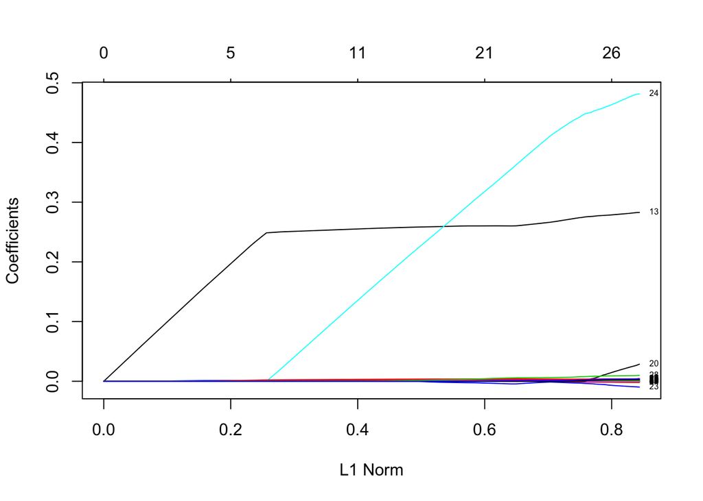

```r
flight.delay.lasso <- flight.delay.final

# Converting factor variables to numeric
flight.delay.lasso$UniqueCarrier <- as.numeric(flight.delay.final$UniqueCarrier)
flight.delay.lasso$FlightDate <- as.numeric(flight.delay.final$FlightDate)
flight.delay.lasso$CancellationCode <- as.numeric(flight.delay.final$CancellationCode)
flight.delay.lasso$Origin <- as.numeric(flight.delay.final$Origin)
flight.delay.lasso$Dest <- as.numeric(flight.delay.final$Dest)
flight.delay.lasso$TailNum <- as.numeric(flight.delay.final$TailNum)
flight.delay.lasso <- select(flight.delay.lasso, -DepDelay.y)

# Extract covariates matrix (for lasso)
flight.delay.lasso.x <- as.matrix(flight.delay.lasso[, -which(names(flight.delay.lasso) == "DepDel15.y")])

# Extract response variable (for lasso)
flight.delay.lasso.y <- flight.delay.lasso$DepDel15.y

# Fitting the model
flight.delay.lasso.fit <- glmnet(x = flight.delay.lasso.x, y = flight.delay.lasso.y)

# Regularization plot
plot(flight.delay.lasso.fit, xvar = "norm", label = TRUE)
```

- **We fit the lasso model on the feature engineered data. The following results are observed:**  
  **- There are 87 lambda value for the model fits.**  
  **- The above regularization plot shows that as more variables are added to the model, the computation will get more complex.**

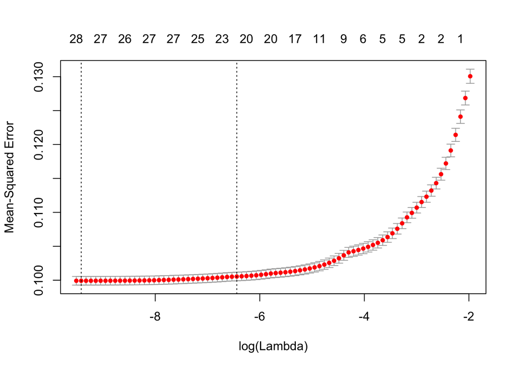

```r
# Perform 10-fold cross validation
flight.delay.lasso.fit.cv <- cv.glmnet(x = flight.delay.lasso.x, y = flight.delay.lasso.y)

# To get CV error plot
plot(flight.delay.lasso.fit.cv)
```

- **The above plot is the CV error plot.**

```r
# Value of lambda that gives min CV error
lambda.min <- flight.delay.lasso.fit.cv$lambda.min

# Value of lambda 1-SE rule tells to use
lambda.1se <- flight.delay.lasso.fit.cv$lambda.1se

# Number of non-zero variables in min-CV rule
length(coef(flight.delay.lasso.fit.cv, s = flight.delay.lasso.fit.cv$lambda.min)[which(coef(flight.delay.lasso.fit.cv, s = "lambda.min") != 0)])
```

```
## [1] 29
```

```r
# Number of non-zero variables in 1-SE rule
length(coef(flight.delay.lasso.fit.cv, s = flight.delay.lasso.fit.cv$lambda.1se)[which(coef(flight.delay.lasso.fit.cv, s = "lambda.1se") != 0)])
```

```
## [1] 22
```

```r
#Estimated CV error for  min-CV rule
flight.delay.lasso.fit.cv$cvm[flight.delay.lasso.fit.cv$lambda == flight.delay.lasso.fit.cv$lambda.min]
```

```
## [1] 0.09991694
```

```r
#Estimated CV error for  1-SE rule
flight.delay.lasso.fit.cv$cvm[flight.delay.lasso.fit.cv$lambda == flight.delay.lasso.fit.cv$lambda.1se]
```

```
## [1] 0.1005444
```

```r
# Coefficients of 1-SE
coef(flight.delay.lasso.fit.cv, s = lambda.1se)
```

```
## 31 x 1 sparse Matrix of class "dgCMatrix"
##                               1
## (Intercept)        1.248455e-01
## Month              1.295786e-03
## UniqueCarrier      2.059917e-03
## FlightDate         2.640126e-05
## DayOfWeek          .
## FlightNum          2.655228e-06
## TailNum           -2.313818e-06
## ActualElapsedTime  .
## CRSElapsedTime     .
## AirTime            7.244604e-05
## ArrDelay           8.390404e-04
## ArrTime            1.497551e-04
## CRSArrTime        -1.599301e-04
## DepDel15           2.602728e-01
## DepDelay           .
## DepTime            5.858348e-05
## CRSDepTime        -1.433937e-04
## Origin            -2.338217e-05
## Dest               .
## Distance           .
## DistanceGroup      .
## TaxiIn             4.048833e-03
## TaxiOut            1.546168e-03
## CancellationCode  -4.240092e-03
## Diverted           3.502385e-01
## CarrierDelay       1.276772e-03
## WeatherDelay       .
## NASDelay           3.321411e-03
## SecurityDelay      5.460540e-03
## LateAircraftDelay  9.596479e-04
## id                 .
```

- **The value of $\lambda$ that minimizes CV error is 8.133058610^{-5}.**
- **The 1-SE rule tells us to use $\lambda$ value of 0.0015966. 29 non-zero variables are selected by the min-CV rule and 22 non-zero variables by the 1-SE rule. The estimated CV error for min-CV model is 0.0999169 and that of 1-SE rule is 0.1005444.**

```r
#Function to generate performance metrics

classMetrics <- function(score, y, cutoff,
                         type = c("all", "accuracy", "sensitivity",
                                  "specificity", "ppv", "npv", "precision",
                                  "recall")) {
  # This command throws an error if the user specifies a "type" that
  # isn't supported by this function
  type <- match.arg(type, several.ok = TRUE)

  #Calc confusion matrix and other values
conf.matrix <- table(predicted = factor(ifelse(score > cutoff, 1, 0), levels = c(0,1)), observed = y)
accuracy <- sum(diag(conf.matrix))/length(score)
sensitivity <- diag(conf.matrix)[2]/colSums(conf.matrix)[2]
specificity <- diag(conf.matrix)[1]/colSums(conf.matrix)[1]
ppv <-  diag(conf.matrix)[2]/rowSums(conf.matrix)[2]
npv <-  diag(conf.matrix)[1]/rowSums(conf.matrix)[1]
precision <- ppv
recall <- sensitivity

if('all' %in% type){
  attributes <- matrix(nrow = 7, ncol=1)

  rownames(attributes) <- c("accuracy", "sensitivity","specificity", "ppv", "npv", "precision", "recall")
  colnames(attributes) <- "value"
  attributes[1,1] <- accuracy
  attributes[2,1] <- sensitivity
  attributes[3,1] <- specificity
  attributes[4,1] <- ppv
  attributes[5,1] <- npv
  attributes[6,1] <- precision
  attributes[7,1] <- recall
}
else {

  attributes <- matrix(nrow = length(type), ncol=1)

  rownames(attributes) <- type
  colnames(attributes) <- "value"

  for(i in 1:length(type)){
  if(rownames(attributes)[i] =="accuracy")
     attributes[i,1] <- accuracy
  if(rownames(attributes)[i] =="sensitivity")
     attributes[i,1] <- sensitivity
  if(rownames(attributes)[i] =="specificity")
     attributes[i,1] <- specificity
  if(rownames(attributes)[i] =="ppv")
     attributes[i,1] <- ppv
  if(rownames(attributes)[i] =="npv")
     attributes[i,1] <- npv
  if(rownames(attributes)[i] =="precision")
     attributes[i,1] <- precision
  if(rownames(attributes)[i] =="recall")
     attributes[i,1] <- recall
  }

}

result <- list(conf.mat = conf.matrix, perf = attributes)
return (result)
}
```

# 7. Logistic Regression Model

```r
#sample data
logReg <- flight.delay.final[sample(nrow(flight.delay.final)), ]

#Remove variables which are not relevant for prediction
logReg <- logReg %>% dplyr :: select(-c(FlightDate,TailNum,id,ArrTime,ArrDelay,CRSArrTime,DistanceGroup,CancellationCode,DepDel15,Dest, DepDelay.y))

#convert to factor
logReg$UniqueCarrier<- as.numeric(logReg$UniqueCarrier)
logReg$Origin <- as.numeric(logReg$Origin)

#Validated logistic model with Cross Validation
# Number of iterations
k <- 10
acc <- NULL
set.seed(123)
folds <- cut(seq(1,nrow(logReg)),breaks=k,labels=FALSE)

for(i in 1:k)
{
# Train-test splitting
# 90% of samples -> fitting
# 10% of samples -> testing
      test.indexes <- which(folds==i,arr.ind=TRUE)
      test.data <- logReg[test.indexes, ]
      train.data <- logReg[-test.indexes, ]

# Fitting
flight.logit <- glm(DepDel15.y~.,family=binomial,data=train.data)

# Predict results
results_prob <- predict(flight.logit, newdata = test.data ,type ="response")

# If prob > 0.5 then 1, else 0
results <- ifelse(results_prob > 0.5,1,0)

# Actual answers
answers <- test.data$DepDel15

# Accuracy calculation
misClasificError <- mean(answers != results)

# Collecting results
acc[i] <- 1-misClasificError
}

# Average accuracy of the model
mean(acc)
```

```
## [1] 0.8591798
```

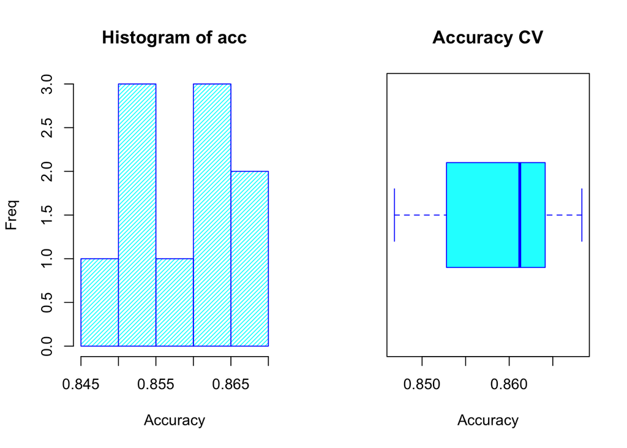

```r
par(mfcol=c(1,2))

# Histogram of accuracy
hist(acc,xlab='Accuracy',ylab='Freq',
col='cyan',border='blue',density=30)

# Boxplot of accuracy
boxplot(acc,col='cyan',border='blue',horizontal=T,xlab='Accuracy',
main='Accuracy CV')
```

# 8. Random Forest Modelling

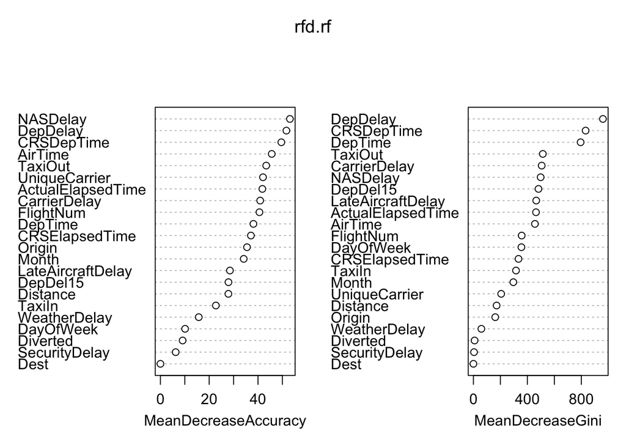

```r
# Changing factor variables to numeric
flight.delay.final$UniqueCarrier<- as.numeric(flight.delay.final$UniqueCarrier)
flight.delay.final$Origin <- as.numeric(flight.delay.final$Origin)
flight.delay.final$Dest <- as.numeric(flight.delay.final$Dest)

flight.delay.rf <- flight.delay.final

flight.delay.rf$DayOfWeek <- as.factor(gsub("1", "MON", flight.delay.rf$DayOfWeek ))
flight.delay.rf$DayOfWeek <- as.factor(gsub("2", "TUE", flight.delay.rf$DayOfWeek ))
flight.delay.rf$DayOfWeek <- as.factor(gsub("3", "WED", flight.delay.rf$DayOfWeek ))
flight.delay.rf$DayOfWeek <- as.factor(gsub("4", "THU", flight.delay.rf$DayOfWeek ))
flight.delay.rf$DayOfWeek <- as.factor(gsub("5", "FRI", flight.delay.rf$DayOfWeek ))
flight.delay.rf$DayOfWeek <- as.factor(gsub("6", "SAT", flight.delay.rf$DayOfWeek ))
flight.delay.rf$DayOfWeek <- as.factor(gsub("7", "SUN", flight.delay.rf$DayOfWeek ))

flight.delay.rf$DepDel15.y <- as.factor(gsub("1", "moreThan15(min)", flight.delay.rf$DepDel15.y ))
flight.delay.rf$DepDel15.y <- as.factor(gsub("0", "lessThan15(min)", flight.delay.rf$DepDel15.y ))

# 70% of the sample size
smp_size <- floor(0.70 * nrow(flight.delay.rf))

# set the seed to make your partition reproductible
set.seed(12345)
train_ind <- sample(seq_len(nrow(flight.delay.rf)), size = smp_size)

rfd.train <- flight.delay.rf[train_ind, ]
rfd.test <- flight.delay.rf[-train_ind, ]

rfd.rf <- randomForest(rfd.train$DepDel15.y ~ . -FlightDate -CancellationCode -TailNum -DepDel15.y -DepDelay.y -id - ArrTime -ArrDelay -CRSArrTime -DistanceGroup, data = rfd.train, importance=TRUE, mtry=3)

varImpPlot(rfd.rf)
```

```r
preds.random <- data.frame(predict(rfd.rf, newdata = rfd.test, type = 'prob'))

classMetrics(preds.random$moreThan15.min. , rfd.test$DepDel15.y , cutoff = 0.17, type = "all")
```

```
## $conf.mat
##          observed
## predicted lessThan15(min) moreThan15(min)
##         0           12807             839
##         1            1582            1773
##
## $perf
##                 value
## accuracy    0.8575966
## sensitivity 0.6787902
## specificity 0.8900549
## ppv         0.5284650
## npv         0.9385168
## precision   0.5284650
## recall      0.6787902
```

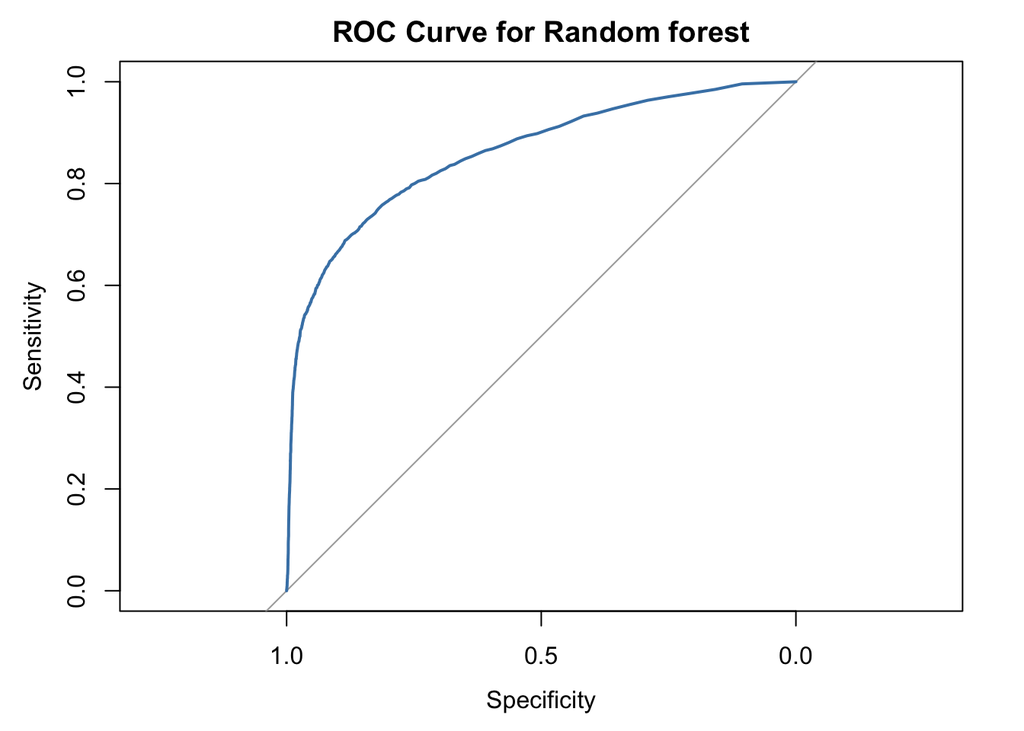

```r
roc.rfd <- roc(rfd.test$DepDel15.y, preds.random$moreThan15.min.)

plot(roc.rfd, col= "steelblue", main = "ROC Curve for Random forest")
```

```r
roc.rfd$auc
```

```
## Area under the curve: 0.8602
```

**Random Forest Model**  
- **A random forest is modelled taking DepDel15.y i.e the DepDel15 for Pittsburgh to other cities as response variable and other variables except Arrival attributes like ArrTime, FlightDate, TailNum and id because these were not helping in any interpretation.** - **We are predicting with cutoff 0.17. We have taken the cutoff as 0.17 because in our problem we are very much concerned about sensitivity since False Negatives are too costly and hence, we correctly need to predict the true flights getting delayed.**

# 9. Validation of Random Forest Model using 2016 Pittsburgh Flight Delay data.

## Feature Engineering

```r
# Change this path to your local drive where you have store the file.
setwd("/Users/priyankakaria/Documents/CMU/Fall/Mini-2/Data Mining/Project/")

flight.delay.2016 <- read.csv("all_PIT_2016.csv",header = TRUE, sep = ",")

flight.delay.2016 <- flight.delay.2016 %>%dplyr :: select(-c(AirlineID, Carrier, Flights, ArrDel15, DepTimeBlk, OriginCityName, OriginStateFips, OriginStateName, OriginState, DestCityName, DestState, DestStateFips, DestStateName, DestWac, WheelsOff, WheelsOn, Year, Quarter, DayofMonth, OriginWac, Cancelled))

flight.delay.2016 <- arrange(flight.delay.2016, FlightDate, TailNum, FlightNum)

flight.delay.pit.2016 <- flight.delay.2016 %>% mutate(id = ifelse(Origin=="PIT", 2, 1))
flight.delay.pit.2016 <- arrange(flight.delay.pit.2016, FlightDate, TailNum, Origin, Dest, id, DepDelay)

flight.delay.pit.2016.1 <- subset(flight.delay.pit.2016, flight.delay.pit.2016$id == 1)

flight.delay.pit.2016.2 <- subset(flight.delay.pit.2016, flight.delay.pit.2016$id == 2)

flight.combine.data.2016 <- left_join (flight.delay.pit.2016.1, flight.delay.pit.2016.2, by = c("TailNum","FlightDate"))

#Combining Data
flight.combine.data.2016 <- select(flight.combine.data.2016, 1:30, DepDelay.y, DepDel15.y )

#Renaming columns
names(flight.combine.data.2016) <- sub(".x$", "", names(flight.combine.data.2016))

flight.delay.2016 <- flight.combine.data.2016
```

## Filling missing data and prediction

```r
#Filling ActualElapsedTime with CRSElapsedTime
flight.delay.2016$ActualElapsedTime <- ifelse(is.na(flight.delay.2016$ActualElapsedTime) == "TRUE", flight.delay.2016$CRSElapsedTime, flight.delay.2016$ActualElapsedTime)

#Removing observations where ActualElapsedTime is missing
flight.delay.2016 <- subset(flight.delay.2016, is.na(flight.delay.2016$ActualElapsedTime)==FALSE)

#Filling ArrTime with CRSArrTime
flight.delay.2016$ArrTime <- ifelse(is.na(flight.delay.2016$ArrTime) == "TRUE", flight.delay.2016$CRSArrTime, flight.delay.2016$ArrTime)

#Filling DepTime with CRSDepTime
flight.delay.2016$DepTime <- ifelse(is.na(flight.delay.2016$DepTime) == "TRUE", flight.delay.2016$CRSDepTime, flight.delay.2016$DepTime)

#Filling ArrDelay with 0
flight.delay.2016$ArrDelay <- ifelse(is.na(flight.delay.2016$ArrDelay) == "TRUE", 0, flight.delay.2016$ArrDelay)

#Filling DepDelay with 0
flight.delay.2016$DepDelay <- ifelse(is.na(flight.delay.2016$DepDelay) == "TRUE", 0, flight.delay.2016$DepDelay)

#Filling AirTime with 0
flight.delay.2016$AirTime <- ifelse(is.na(flight.delay.2016$AirTime) == "TRUE",0,flight.delay.2016$AirTime)

#Filling DepDel15 with 0
flight.delay.2016$DepDel15 <- ifelse(is.na(flight.delay.2016$DepDel15) == "TRUE", 0, flight.delay.2016$DepDel15)

#Filling CarrierDelay with 0
flight.delay.2016$CarrierDelay <- ifelse(is.na(flight.delay.2016$CarrierDelay) == "TRUE", 0, flight.delay.2016$CarrierDelay)

#Filling WeatherDelay with 0
flight.delay.2016$WeatherDelay <- ifelse(is.na(flight.delay.2016$WeatherDelay) == "TRUE", 0, flight.delay.2016$WeatherDelay)

#Filling NASDelay with 0
flight.delay.2016$NASDelay <- ifelse(is.na(flight.delay.2016$NASDelay) == "TRUE", 0, flight.delay.2016$NASDelay)

#Filling SecurityDelay with 0
flight.delay.2016$SecurityDelay <- ifelse(is.na(flight.delay.2016$SecurityDelay) == "TRUE", 0, flight.delay.2016$SecurityDelay)

#Filling LateAircraftDelay with 0
flight.delay.2016$LateAircraftDelay <- ifelse(is.na(flight.delay.2016$LateAircraftDelay) == "TRUE", 0, flight.delay.2016$LateAircraftDelay)

#Filling CancellationCode with 0
flight.delay.2016$CancellationCode <- ifelse(is.na(flight.delay.2016$CancellationCode) == "TRUE", 0, flight.delay.2016$CancellationCode)

#Filling TaxiIn with 0
flight.delay.2016$TaxiIn <- ifelse(is.na(flight.delay.2016$TaxiIn) == "TRUE", 0, flight.delay.2016$TaxiIn)

#Filling TaxiOut with 0
flight.delay.2016$TaxiOut <- ifelse(is.na(flight.delay.2016$TaxiOut) == "TRUE", 0, flight.delay.2016$TaxiOut)

#Filling DepDel15 with 0
flight.delay.2016$DepDel15.y <- ifelse(is.na(flight.delay.2016$DepDel15.y) == "TRUE",0,flight.delay.2016$DepDel15.y)
flight.delay.2016$DepDelay.y <- ifelse(is.na(flight.delay.2016$DepDelay.y) == "TRUE",0,flight.delay.2016$DepDelay.y)

#Converting delays to positive values
flight.delay.2016$ArrDelay <- ifelse(flight.delay.2016$ArrDelay < 0, 0, flight.delay.2016$ArrDelay)
flight.delay.2016$DepDelay <- ifelse(flight.delay.2016$DepDelay < 0, 0, flight.delay.2016$DepDelay)
flight.delay.2016$DepDelay.y <- ifelse(flight.delay.2016$DepDelay.y < 0, 0, flight.delay.2016$DepDelay.y)

flight.delay.2016$DayOfWeek <- as.factor(gsub("1", "MON", flight.delay.2016$DayOfWeek ))
flight.delay.2016$DayOfWeek <- as.factor(gsub("2", "TUE", flight.delay.2016$DayOfWeek ))
flight.delay.2016$DayOfWeek <- as.factor(gsub("3", "WED", flight.delay.2016$DayOfWeek ))
flight.delay.2016$DayOfWeek <- as.factor(gsub("4", "THU", flight.delay.2016$DayOfWeek ))
flight.delay.2016$DayOfWeek <- as.factor(gsub("5", "FRI", flight.delay.2016$DayOfWeek ))
flight.delay.2016$DayOfWeek <- as.factor(gsub("6", "SAT", flight.delay.2016$DayOfWeek ))
flight.delay.2016$DayOfWeek <- as.factor(gsub("7", "SUN", flight.delay.2016$DayOfWeek ))

flight.delay.2016$DepDel15.y <- as.factor(gsub("1", "moreThan15(min)", flight.delay.2016$DepDel15.y ))
flight.delay.2016$DepDel15.y <- as.factor(gsub("0", "lessThan15(min)", flight.delay.2016$DepDel15.y ))

flight.delay.2016$UniqueCarrier<- as.numeric(flight.delay.2016$UniqueCarrier)
flight.delay.2016$Origin <- as.numeric(flight.delay.2016$Origin)
flight.delay.2016$Dest <- as.numeric(flight.delay.2016$Dest)


preds.random <- data.frame(predict(rfd.rf, newdata = flight.delay.2016, type = 'prob'))

classMetrics(preds.random$moreThan15.min. , flight.delay.2016$DepDel15 , cutoff = 0.17, type = "all")
```

```
## $conf.mat
##          observed
## predicted     0     1
##         0 15136  1190
##         1  6642  3383
##
## $perf
##                 value
## accuracy    0.7027817
## sensitivity 0.7397770
## specificity 0.6950133
## ppv         0.3374564
## npv         0.9271101
## precision   0.3374564
## recall      0.7397770
```

# 10. Comparing with 2016 Data

```r
setwd("/Users/priyankakaria/Documents/CMU/Fall/Mini-2/Data Mining/Project/")

flight.delay.2016 <- read.csv("all_PIT_2016.csv",header = TRUE, sep = ",")

flight.delay.2016 <- flight.delay.2016 %>%dplyr :: select(-c(AirlineID, Carrier, Flights, ArrDel15, DepTimeBlk, OriginCityName, OriginStateFips, OriginStateName, OriginState, DestCityName, DestState, DestStateFips, DestStateName, DestWac, WheelsOff, WheelsOn, Year, Quarter, DayofMonth, OriginWac, Cancelled))

kable(field.summary(flight.delay.2016))
```

| colnames | dataType | factorLevels | mean | sd | missingValues |
| --- | --- | --- | --- | --- | --- |
| Month | integer | 0 | 6.6553360 | 3.3896744 | 0 |
| DayOfWeek | integer | 0 | 3.9117984 | 1.9775082 | 0 |
| FlightDate | factor | 366 | 0.0000000 | 0.0000000 | 0 |
| UniqueCarrier | factor | 8 | 0.0000000 | 0.0000000 | 0 |
| TailNum | factor | 2924 | 0.0000000 | 0.0000000 | 0 |
| FlightNum | integer | 0 | 1927.2905534 | 1338.0184095 | 0 |
| Origin | factor | 30 | 0.0000000 | 0.0000000 | 0 |
| Dest | factor | 30 | 0.0000000 | 0.0000000 | 0 |
| CRSDepTime | integer | 0 | 1333.2960870 | 491.6011367 | 0 |
| DepTime | integer | 0 | 1336.3651747 | 504.4052845 | 487 |
| DepDelay | integer | 0 | 6.9387185 | 34.3400908 | 487 |
| DepDel15 | integer | 0 | 0.1504201 | 0.3574862 | 487 |
| TaxiOut | integer | 0 | 14.8353528 | 8.2890836 | 505 |
| TaxiIn | integer | 0 | 7.1079743 | 5.1271077 | 514 |
| CRSArrTime | integer | 0 | 1471.3505336 | 541.0998900 | 0 |
| AirTime | integer | 0 | 1450.0429661 | 555.9255011 | 514 |
| ArrDelay | integer | 0 | 0.7196985 | 36.4524713 | 586 |
| ArrTime | factor | 20 | 0.0000000 | 0.0000000 | 0 |
| CancellationCode | factor | 4 | 0.0000000 | 0.0000000 | 0 |
| Diverted | integer | 0 | 23.2891107 | 57.4915390 | 0 |
| CRSElapsedTime | integer | 0 | 132.0853188 | 61.1720930 | 107 |
| ActualElapsedTime | integer | 0 | 122.9086256 | 61.2268041 | 586 |
| Distance | integer | 0 | 760.0618379 | 506.3711328 | 0 |
| DistanceGroup | integer | 0 | 3.5789723 | 2.0938684 | 0 |
| CarrierDelay | integer | 0 | 21.8237879 | 55.2851635 | 43319 |
| WeatherDelay | integer | 0 | 2.4345557 | 17.6365749 | 43319 |
| NASDelay | integer | 0 | 10.2409010 | 22.4247014 | 43319 |
| SecurityDelay | integer | 0 | 0.0977888 | 2.6075328 | 43319 |
| LateAircraftDelay | integer | 0 | 25.2355446 | 42.0815389 | 43319 |

** As we can see in the summary, in 2016, average departure delay reduce from PIT aiport implying that the airport is performing well these days. **

**In conclusion, flight departure delay at PIT airport can be fairly predicted using a random forest model. Since PIT airport has most of the flights coming in from different cities and so the delay in departure is highly based on delay by which the particular aircraft comes to PIT which is predicted in our model by Departure Delay from origin where the aircraft is coming from.**